# ExPanD - Explore your data!

## ExPanD - Explore your data!

Welcome to ExPanD! To start exploring your data, please upload a data file containing at least two numerical variables. For panel data, the data needs to be in long format and without duplicate observations. Currently supported formats are Excel, CSV, RData, RDS, STATA and SAS.

Browse...

Select cross sectional identifier(s)

Row names

Select the variable(s) that (together) identif(y/ies) a cross-sectional unit. Selecting multiple variables is possible. You can use the row names of the data frame to identify cross-sectional data.

Select time series identifier

None

Select the variable that identifies a the time series. It needs to be coercible into an ordered factor. If you select 'None', then the data is treated as cross-sectional.

Subset factor

Full Sample

Indicate whether you want to study the full sample or subset to a specific factor.

Group factor

sex

Select a factor for subsetting specific analyses to.

Outlier treatment

No treatment

Winsorization 1%/99%

Winsorization 5%/95%

Truncation 1%/99%

Truncation 5%/95%

By group factor

None

Indicate whether you want no outlier treatment or whether you want outliers to be winsorized to the given percentile or truncated if they exceed the given percentile. Give a by group if you want outlier treatment to be done independently by group.

### Bar Chart

Select factor to display

school

Select additional factor to display

sex

Relative display

Check if you want to see the additional factor relative to the first factor.

Select group to subset to

All

Loading...

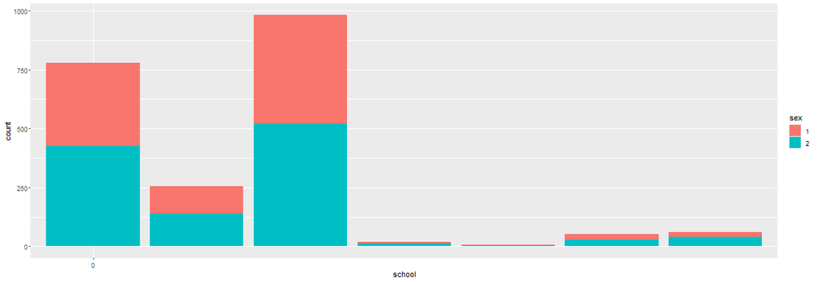

Enter name for your additional variable

If you want to create additional variables for the analysis, provide a name (must not be taken) and a definition here. A definition can consist of the base set variables, parentheses and the operators '+', '-', '*', '/', '==', '&', '|', '<', '>', '!', 'is.na()', '^', 'exp()', 'log()', 'lead()' and 'lag()'.

Enter definition for your additional variable

### Descriptive Statistics

Hover over variable names with mouse to see variable definitions. Select Tab to choose the analysis set of variables or the base set of variables (to define new variables).

Select group to subset to

All

Click here to delete selected variables from the analysis sample.

Click here to delete all user defined variables and to restore the original variable set of the analysis sample.

- Analysis Set
- Base Set

[interactive table not shown]

### Histogram

Select variable to display

age

Select group to subset to

All

Suggested number of cells 25020

Loading...

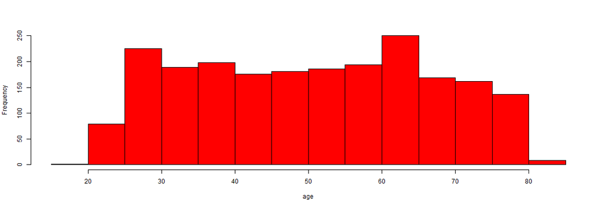

### Extreme Observations

Select variable to sort data by

id

Select group to subset to

All

| cs_id | sex | id |
| --- | --- | --- |
| 815 | 1 | 7,607 |
| 2007 | 1 | 7,606 |
| 973 | 1 | 7,603 |
| 1957 | 2 | 7,602 |
| 1775 | 2 | 7,600 |
| ... | ... | ... |
| 1387 | 2 | 3,309 |
| 1831 | 2 | 3,307 |
| 1284 | 1 | 3,305 |
| 716 | 1 | 3,303 |
| 1623 | 2 | 3,301 |

### By Group Bar Chart

Select variable to display

age

Select variable to group by

family

Select statistic to display

Mean

Sort by statistic

Select group to subset to

All

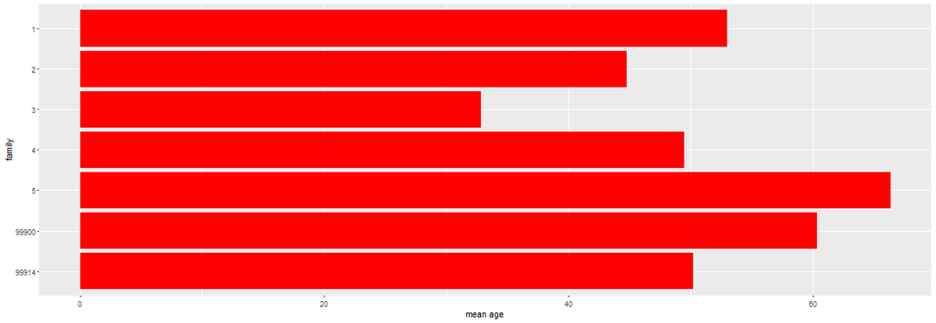

### By Group Violin Chart

Select variable to display

sbp1

Select variable to group by

sex

Sort by group means

(Note: Consider treating your outliers if this graph looks odd)

Select group to subset to

All

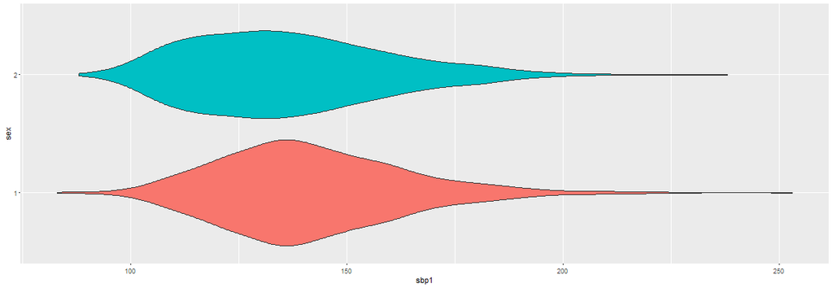

### Correlation Plot

This plot visualizes sample correlations (Pearson above, Spearman below diagonal). Reports correlations for all continuous variables. Hover over ellipse to get rho, P-Value and n.

Select group to subset to

All

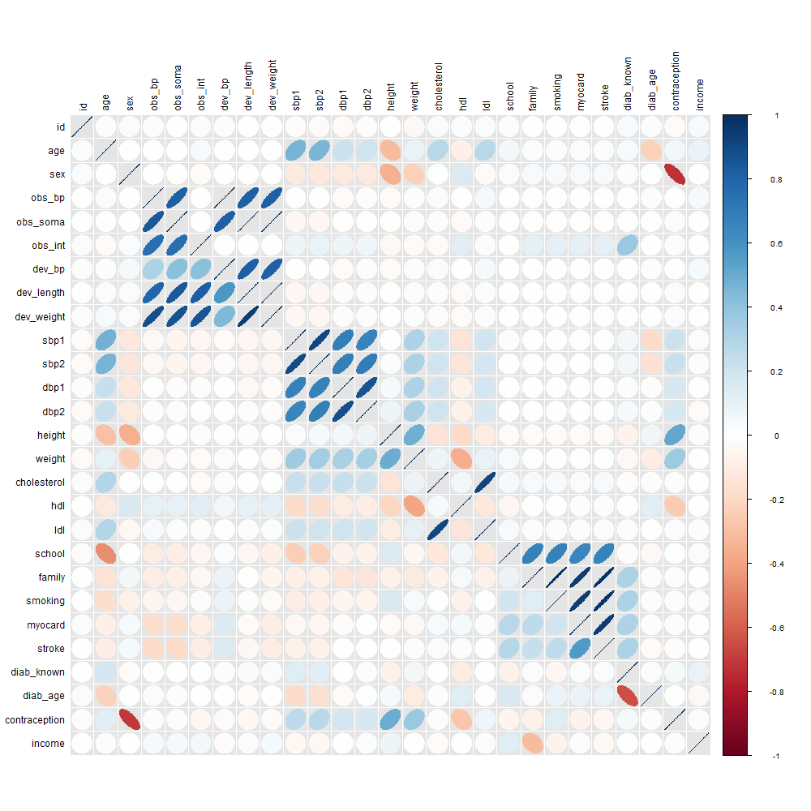

### Scatter Plot

Select the x variable to display

weight

Select the y variable to display

hdl

Select the variable to be reflected by dot size

sex

Select the variable to be reflected by color

sex

Sample 1,000 observations to display if number of observations is higher

Display smoother

(Note: This might take a while to compute for large samples)

Select group to subset to

All

Loading...

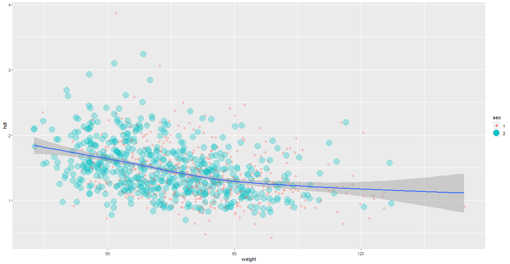

### Regression Analysis

Select the dependent variable

hdl

Select independent variable(s)

weight

Select a categorial variable as the first fixed effect

None

Select a categorial variable as the second fixed effect

None

Select a categorial variable to subset the estimated models on

None

Calculation of Standard Errors

Standard

Indicate how you want your standard errors to be estimated

|  | *Dependent variable:* |
| --- | --- |
|  | hdl |
| weight | -0.011*** |
|  | (0.001) |
| Constant | 2.281*** |
|  | (0.046) |
| Estimator | ols |
| Fixed effects | None |
| Std. errors clustered | No |
| Observations | 2,135 |
| R<sup>2</sup> | 0.135 |
| Adjusted R<sup>2</sup> | 0.135 |
| *Note:* | *p<0.1; **p<0.05; ***p<0.01 |

[Save Settings](http://127.0.0.1:7004/session/f81f17a917fd46a479899ff6f40a0265/download/download?w=) Click here to save ExPanD settings to your local environment.

Browse...

Select RDS file to load locally stored settings.

ExPanD based on ExPanDaR, [Joachim Gassen](https://twitter.com/JoachimGassen), [Humboldt-UniversitÃ¤t zu Berlin](https://www.wiwi.hu-berlin.de/rewe) and [TRR 266 Accounting for Transparency](https://www.accounting-for-transparency.de/), 2020